## Human Activities

#### Fishing

##### Landings

###### Commercial

![**Figure App.C.4.4.**. A figure showing trends in landings (lbs, left y-axis) and econmic value (dollars, right y-axis) for seven major fisheries around the Channel Islands (2000 - 2012).

Trends over time in commercial fishing activity in Channel Islands National Marine Sanctuary (CINMS) based on landings pounds (blue bars) and value (dark blue line) for seven fisheries from 2000 to 2012. Landings were combined for twenty-two blocks that overlap substantially with the sanctuary (see Figure App.C4.3. for map). Landings for market squid, sardine, and anchovy declined recently while landings of crabs increased. Landings of sea urchin, spiny lobster, and prawn and shrimp were relatively stable. Figure: Leeworthy et al. 2014a](../img/cinms_cr/App.C.4.4.Leeworthy_landings.jpg)

###### Recreational

![**Figure App.C.4.2.**. A figure of Commercial Passenger Fishing Vessel (CPFV) trips and anglers per trip accross years (2000 - 2012).

Fishing activity landings for Commercial Passenger Fishing Vessels (CPFVs) operating out of ports in Santa Barbara and Ventura from 2000 to 2012. Activity landings in 2011 and 2012 returned to levels seen in the early 2000s. Figure: Chen et al. 2015b](../img/cinms_cr/App.C.4.2b.CPFV_landings.jpg)

###### Deep-water

![**Figure App.C.3.2.**. A figure showing (near) bottom-dwelling fish landings reported from within the sanctuary from 1985 - 2015.

Landings (in pounds) and the relative contribution of gear types has changed over time due to changing regulations, economics, and consumer demand. Since 2002, there is zero to minimal set net and trawl landings, and reduced landings for bottom longlines and traps until 2008, followed by a dramatic increase in bottom longline and trap landings to peak levels. Data source: CDFW; Figure: [P. Etnoyer/NOAA](https://oceanexplorer.noaa.gov/edu/oceanage/03etnoyer/welcome.html)](../img/cinms_cr/App.C.3.2_CINMSLandings.jpg)

##### Maps of Fishing

###### Trawling

![**Figure App.C.3.3.**. A map showing commerical trawling landings across the Southern California Bight (2007-2011). Locations of known deep-water corals, which are very vulnerable to trawling, are indicated on the map.

Trawling landings across the Southern California Bight, as illustrated by CDFW 10 square kilometer blocks and shown along with known locations of stony deep-water corals. Trawling is known to disturb bottom habitats and deep-sea corals. Even though trawling effort has decreased in recent years, the impacts of this gear type can be long lived. Data source: CDFW, Perry et al 2010; Map: [P. Etnoyer/NOAA](https://oceanexplorer.noaa.gov/edu/oceanage/03etnoyer/welcome.html), Etnoyer et al. 2015](../img/cinms_cr/App.C.3.3_SWFSC_Trawls2007-2011_HBCoralsRS.jpg)

###### Fixed Gear

![**Figure App.C.3.4.**. A map showing historal landings of fixed gear across the Southern California Bight (2007-2011). Locations of known deep-water gorgonians, which are very vulnerable to trawling, are indicated on the map.

Historical landings of fixed gear that could impact benthic habitats are shown along with the locations of deep-sea gorgonians in the map above. Fixed gear usage is moderate around the Channel Islands and likely impacts gorgonians in CINMS habitats. Data is from 2007 to 2011. Data source: CDFW, Perry et al 2010; Map: [P. Etnoyer/NOAA](https://oceanexplorer.noaa.gov/edu/oceanage/03etnoyer/welcome.html), Etnoyer et al. 2015](../img/cinms_cr/App.C.3.4_SWFSC_Fixed2007-2011_Gorgonians.jpg)

###### Trawl & Fixed Gear with MPAs

![**Figure App.C.3.5.**. A map showing the locations of both trawling and fixed gear fishing in relation to protected areas (2007-2011) within the Southern California Bight.

Overlay of trawl and fixed gear fishing activity from 2007 to 2011 and protected areas is shown in the map above. Much of the landings is off the Santa Barbara mainland coast; however, fixed gear usage regularly occurs in sanctuary waters. Data source: CDFW; Map: [P. Etnoyer/NOAA](https://oceanexplorer.noaa.gov/edu/oceanage/03etnoyer/welcome.html)](../img/cinms_cr/App.C.3.5_SoCalDeepBotFishingMPAs_Etnoyer.jpg) ## Human Impacts

#### Acidification

##### Aragonite saturation

![**Figure App.E.10.29.**. A figure showing different aragonite (calcium carbonate) solution or dissolution (saturation) at different depths at Anacapa Island from 2007 - 2014.

Aragonite saturations are shown at 75 meters (m) (green), 150 m (blue) and 300 m (red) at Anacapa Island. As pH of seawater decreases (e.g., from the deposition of atmospheric CO2), the saturation state of aragonite (Ωarg) decreases. Aragonite undersaturation (Ωarg < 1) favors dissolution over calcification, making it harder for organisms to make and maintain their shells or skeletons in the case of corals. In coastal upwelling zones, such as the California Current, the aragonite saturation state and depth are variable and shallow, respectively. With ocean acidification, aragonite saturation depths have shoaled over the past three decades and are now typically around 200 m in the California Current (Turi et al. 2016). At the local scale at Anacapa Island, the aragonite saturation depth has hovered around 130 m over the past eight years. As strong of a shoaling trend as at the California Current scale has not been seen. Instead, he usual seasonal variation but relatively stable aragonite saturation states over time (no trend), particularly in deep water, have been seen. Figure: Etnoyer et al. 2015](../img/cinms_cr/App.E.10.29.jpg)

#### Contaminants

###### Domoic Acid

![**Figure App.D.7.1.**. A figure showing domoic acid levels in commercially-important crustaceans (triangles) and bivalves (circles) collected from the Santa Barbara Channel (2012 - 2013). Red coloration indiciates that the domic acid levels measured above the California Department of Public Health and U.S. Food and Drug Administration action limits.

Domoic acid levels in parts per million (ppm) in commercially-important crustaceans (triangles) and bivalves (circles) collected from the Santa Barbara Channel between 2012 and 2013 are shown on the y-axis for (A) animals collected near the shore of the mainland coast, and (B) animals collected offshore the mainland coast or near the northern Channel Islands. In the cases that are colored red, domoic acid levels measured above the California Department of Public Health and U.S. Food and Drug Administration action limits: 20 ppm for meat and 30 ppm for viscera. Figure: [C. Culver/CA Sea Grant](https://caseagrant.ucsd.edu/profile/carolynn-culver), unpublished data](../img/cinms_cr/App.D.7.1_DA levels in crustaceans and bivalves in 2012 and 2013_C. Culver CA Sea Grant copy.jpg)

###### Harmful Algal Bloom (May 2015)

![**Figure App.D.7.3.**. A map showing an unprecedented West Coast-wide harmful algal bloom (HAB) that extended from the Gulf of Alaska to southern California. March 2015 (left, before the HAB) as compared to May (right, during the HAB).

In May 2015, an unprecedented West Coast-wide harmful algal bloom (HAB) extended from the Gulf of Alaska to southern California. The bloom was composed of *Pseudo-nitzschia*, a toxigenic diatom that has the ability to produce domoic acid, a potent neurotoxin that can cause amnesic shellfish poisoning (ASP) and threaten human health if affected shellfish are consumed. These satellite images show chlorophyll-a estimates averaged over the periods of March 27–31, 2015 (left panel), and May, 6–8, 2015 (right panel). Data source: Satellite data were obtained from the National Aeronautics and Space Administration Ocean Biology Processing Group (OBPG) using a combination of the MODerate resolution Imaging Spectroradiometer (MODIS) on Aqua and Visible Infrared Imaging Radiometer Suite (VIIRS) chlorophyll products. Data were processed using standard OBPG processing with 4 kilometer imagery. Figure: McCabe et al. 2016](../img/cinms_cr/App.D.7.3_2015 HAB_McCabe et al. 2016.jpg)

###### Benthic Response Index - Trend by region

![**Figure App.E.11.10.**. A figure showing comparisons of the Benthic Response Index across different regions of the Southern California Bight.

Comparisons of the Benthic Response Index (BRI), a diversity index of contaminant tolerant and sensitive infauna, among different regions of the Southern California Bight is shown. Island shelf sites (upper right) had been at reference levels (highest ranking) until 2013, when approximately 30 percent of sites were reclassified as low impact. Other regions in the bight did not experience such a large BRI decline as the island shelf, which indicates potential new impacts to sediments around southern California Islands. Figure: K. Schiff/[SCCWRP](https://www.sccwrp.org/)](../img/cinms_cr/App.E.11.10.jpg)

###### Benthic Response Index - Condition by site

![**Figure App.E.11.11.**. A map showing sediment sample locations and their respective Benthic Reponse Index sites from a 2013 Southern California Bight-wide survey.

SCCWRP sediment sample locations and their respective Benthic Response Index (BRI) from the 2013 bight-wide survey are shown in the map. In order to create the BRI, infaunal invertebrate communities are characterized based on the proportion of taxa present in a sample that are sensitive to as opposed to tolerant of contaminant levels. Using a composite score of the infauna community, SCCRWP labels sample sites as reference, low impact, moderate impact, or high impact. Figure: K. Schiff/[SCCWRP](https://www.sccwrp.org/)](../img/cinms_cr/App.E.11.11.jpg)

###### DDT in sediments

![**Figure App.E.11.12.**. A map showing DDT contaminant levels in sediments sampled across the Southern California Bight in 2008.

Dichlorodiphenyltrichloroethane (DDT) contaminant levels in sediment sampling locations during SCCRWP’s 2008 bight-wide survey are shown in the map. DDT is most prominent around the Ports of Long Beach, Los Angeles, and Santa Monica Bay. DDT is a legacy contaminant, which means it persists in the environment long after introduction. A large amount of DDT in the bight came from the dumping of the contaminant by the Montrose Chemical Company off Palos Verdes until the early 1980s, which is why the surrounding areas have high DDT levels. CINMS is relatively far from the spill site and thus, has limited DDT concentrations in sediments. Figure: Schiff et al. 2011](../img/cinms_cr/App.E.11.12.jpg)

###### Copper in sediments

![**Figure App.E11.13.**. A map showing copper contaminant levels in sediments sampled across the Southern California Bight in 2008.

Copper contaminant levels at sediment sampling locations during SCCRWP’s 2008 Bight wide survey are shown in the map. Copper is a heavy metal contaminant that in high concentrations can be toxic to living marine resources. Concentrations in CINMS are consistently low compared with other regions in the southern California Bight. Figure: Schiff et al. 2011.](../img/cinms_cr/App.E.11.13.jpg)

###### Silver in sediments

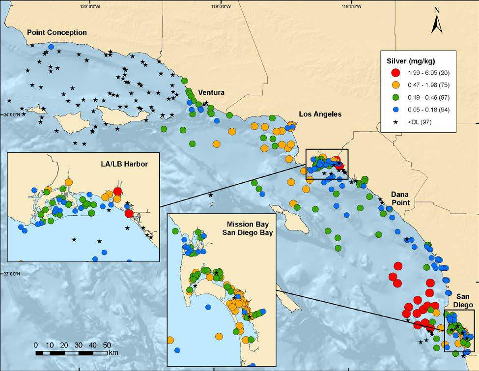

**Figure App.E11.14.**.

###### PBDEs in sediments

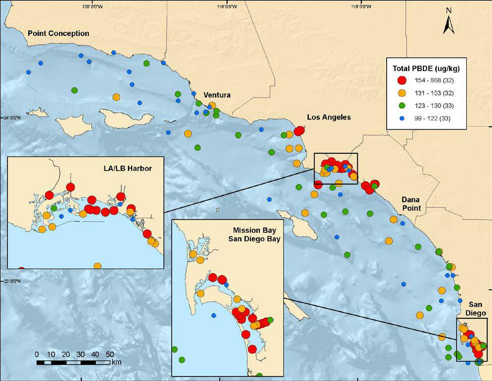

**Figure App.E.11.15.**.

###### Pyrethroids in sediments

![**Figure App.E.11.16.**. A map showing pyrethroid (insecticide) contaminant levels in sediments sampled across the Southern California Bight in 2008.

Pyrethroids contaminant levels in sediment sampling locations during SCCRWP’s 2008 bight-wide survey are shown in the map. Pyrethroids are typically pollutants coming from insecticide use. In recent years, there has been no agriculture on the islands and thus, pyrethroids are absent from CINMS sediments. Sediments adjacent to CINMS off Ventura have low levels of pyrethroids likely due to agriculture in that area. Figure: Schiff et al. 2011](../img/cinms_cr/App.E.11.16.jpg)

###### Contaminants in sediments - Trends by region

![**Figure App.E.11.17.**. A figure showing percent area of impacted sediment by varying catagories of exposure to sediment contamination (“Cat”) across five sites and three years.

Percent area of impacted sediments by stratum and survey year in varying categories of exposure to sediment contamination are shown in the bar plot. Category 1 is minimal exposure; Category 2 is low exposure; Category 3 is moderate exposure; and Category 4 is high exposure. Categories are determined by two prominent chemistry indices determined by analyzing a suite of chemical concentrations present in sediment samples. Missing bars represent no data. In minimal exposure, sediment-associated contamination may be present, but exposure is unlikely to result in effects. In low exposure, small increase in contaminant exposure may be associated with increased effects, but magnitude or frequency of occurrence of biological impacts is low. In moderate exposure, there is clear evidence of sediment contaminant exposure at concentrations that are likely to result in biological effects. For high exposure, contaminant exposure is highly likely to result in substantial biological effects. The Channel Islands have no sediments in Category 4 and the large majority of sediments are in Category 1 or 2, thus indicating limited contamination impact in sanctuary sediments. At this time, the suites of chemical indices have not yet been completed for the 2008 bight-wide survey. Figure: Schiff et al. 2011](../img/cinms_cr/App.E.11.17.jpg)

###### Arsenic in mussels

![**Figure App.E.11.2.**. A figure showing a time series of arsenic found in mussel tissue from Santa Cruz Island from 1986 - 2010.

Time series of arsenic (as μg/g dry weight) in *Mytilus* spp. at Fraser Point, Santa Cruz Island is shown above. Data is from NOAA’s Mussel Watch Program (monitored 1986-2010). Arsenic values have been slowly declining in *Mytilus* spp tissue. Arsenic can impact a number of enzymes and has a widespread effects on a number of organ systems. There are multiple potential explanations for this finding, including limited spatial resolution, limited recent data, possible return to background levels consistent with the southern California mainland after remediation, or improved instrumentation and analytics that have been developed since data collection began. Due to this, more through research and data collection is required to confirm this trend. Figure: D. Whitall/[NOAA, Mussel Watch](https://www.waterboards.ca.gov/water_issues/programs/swamp/mussel_watch.html)](../img/cinms_cr/App.E.11.2.jpg)

###### Iron in mussels

![**Figure App.E.11.3.**. A figure showing a time series of iron found in mussel tissue from Santa Cruz Island from 1986 - 2010.

Time series of iron (as μg/g dry weight) in *Mytilus* spp. at Fraser Point, Santa Cruz Island is shown above. Data is from NOAA’s Mussel Watch Program (monitored 1986–2010). Iron values have been slowly declining in *Mytilus* spp. tissue. There are multiple potential explanations for this finding, including limited spatial resolution, limited recent data, possible return to background levels consistent with the southern California mainland after remediation, or improved instrumentation and analytics that have been developed since data collection began. Due to this, more through research and data collection is required to confirm this trend. Figure: D. Whitall/[NOAA, Mussel Watch](https://www.waterboards.ca.gov/water_issues/programs/swamp/mussel_watch.html)](../img/cinms_cr/App.E.11.3.jpg)

###### Silver in mussels

![**Figure App.E.11.4.**. A figure showing a time series of silver found in mussel tissue from Santa Cruz Island from 1986 - 2010.

Time series of silver (as μg/g dry weight) in *Mytilus* spp. at Fraser Point, Santa Cruz Island is shown above. Data is from NOAA’s Mussel Watch Program (monitored 1986–2010). Silver values have been slowly declining in *Mytilus* spp. tissue. There are multiple potential explanations for this finding, including limited spatial resolution, limited recent data, possible return to background levels consistent with the southern California mainland after remediation, or improved instrumentation and analytics that have been developed since data collection began. Due to this, more through research and data collection is required to confirm this trend. Figure: D. Whitall/[NOAA, Mussel Watch](https://www.waterboards.ca.gov/water_issues/programs/swamp/mussel_watch.html)](../img/cinms_cr/App.E.11.4.jpg)

###### Heavy metals in mussels

![**Figure App.E.11.5.**. A figure showing a coastwide comparison of heavy metals found in mussel tissue from 1986-2010.

This graph is a California coastwide comparison of total extractables (TE) from *Mytilus* spp. tissue for heavy metals. Data is from NOAA’s Mussel Watch Program (monitored 1986–2010). The horizontal lines of the red box illustrate the 25th, median, and 75th percentiles, while the top and bottom whiskers represent the 10th and 90th percentiles. Black dots are data points from collection sites and the green ellipsoids represent mean concentration values for metals from sites within CINMS (n = 3). There are multiple potential explanations for this finding, including limited spatial resolution, limited recent data, possible return to background levels consistent with the southern California mainland after remediation, or improved instrumentation and analytics that have been developed since data collection began. Due to this, more through research and data collection is required to confirm this trend. Figure: D. Apeti/[NOAA, Mussel Watch](https://www.waterboards.ca.gov/water_issues/programs/swamp/mussel_watch.html)](../img/cinms_cr/App.E.11.5.jpg)

###### PAHs in mussels

![**Figure App.E.11.6.**. A figure showing levels of organic, carcinogenic, petroleum-linked chemicals found in the Channel Islands (blue) and offshore sites (red).

Mean Total Extractables (TE) for individual Polycyclic Aromatic Hydrocarbons or PAHs are compared between Channel Islands (blue) and other offshore sites (red). PAHs are organic contaminants that are carcinogenic. Invertebrate species typically have limited ability to metabolize PAHs; however, they typically do not biomagnify because vertebrates can metabolize them more easily. Concentrations of PAHs are variable, but concentrations at CINMS are usually equivalent, if not lower than other offshore locations. There are multiple potential explanations for this finding, including limited spatial resolution, limited recent data, possible return to background levels consistent with the southern California mainland after remediation, or improved instrumentation and analytics that have been developed since data collection began. Due to this, more through research and data collection is required to confirm this trend. Figure: D. Apeti/[NOAA, Mussel Watch](https://www.waterboards.ca.gov/water_issues/programs/swamp/mussel_watch.html)](../img/cinms_cr/App.E.11.6.jpg)

#### Marine Debris

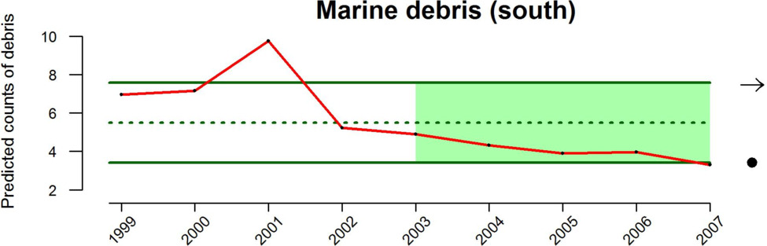

**Figure App.C.4.14.** Marine debris estimates modeled along the mainland southern California coast based on debris measured by the National Marine Debris Monitoring Program. Marine debris was relatively constant across the last five years of this time series (1999-2007) and within historic levels. Data source: Ribic et al. 2012; Figure: K. Andrews/NOAA

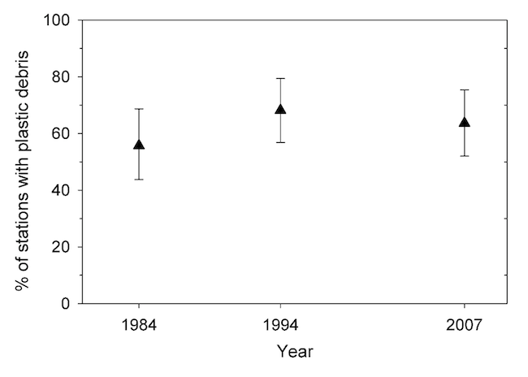

**Figure App.C.4.15.** Variation over time in percentage of stations from winter CalCOFI cruises with plastic micro-debris. Micro-debris was present in more than 50 percent of samples at each time period. Figure: Gilfillan et al. 2009

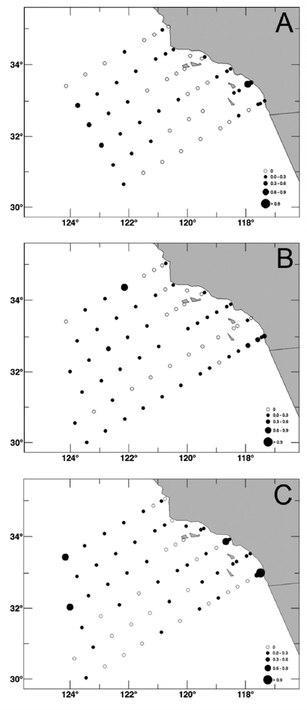

**Figure App.C.4.16.** Spatial distribution, concentration, and characteristics of plastic micro-debris in net samples from the CalCOFI region from winter cruises in (A) 1984, (B) 1994, and (C) 2007. Open circles indicate no plastic debris detected and filled circle diameter are proportional to particle concentrations (number per cubic meter). There was no relationship between the numerical concentration of particles and distance from shore, the presumed source of the majority of debris. Figure: Gilfillan et al. 2009